# Summer Bridge R, Module 5: Programming

August 2019, UC Berkeley

Chris Paciorek

# Loops

In many languages, looping (for loops, while loops, etc.) is one of the main constructs used to carry out computation. Loops are not emphasized as much in R, both because they can be slow and because other syntax is often cleaner.

But there are lots of times when using a loop does make sense.

Most of you are probably familiar at least with the basic idea of iterating through a series of steps. A for loop iterates through a pre-determined number of iterations, while a while loop iterates until some condition is met. For loops are more common in R, but while loops can be handy particularly for things like optimization.

Let's take our use of `aggregate()` from Module 4 and use a for loop instead.

```r
out <- list()
years <- unique(gap$year)
length(out) <- length(years)
names(out) <- years

for (yrIdx in seq_along(years)) {
     # equivalently: for(i in 1:length(years))
     # n.b., seq_along(x) is better than 1:length(x), since it handles the case
     # where the length of an object is 0 or NULL more robustly.
     sub <- subset(gap, gap$year == years[yrIdx])
     if (sum(!is.na(sub$lifeExp)) && length(sub$lifeExp) > 1) {
     # fit regression
       out[[yrIdx]] <- lm(lifeExp ~ log(gdpPercap), data = sub)
     } else {
       out[[yrIdx]] <- NA
     }
}
out[['2007']]
```

```
##
## Call:
## lm(formula = lifeExp ~ log(gdpPercap), data = sub)
##
## Coefficients:
##    (Intercept)  log(gdpPercap)
##          4.950           7.203
```

```r
summary(out[['2007']])
```

```
##
## Call:
## lm(formula = lifeExp ~ log(gdpPercap), data = sub)
##
## Residuals:
##     Min      1Q  Median      3Q     Max
## -25.947  -2.661   1.215   4.469  13.115
##
## Coefficients:
##                Estimate Std. Error t value Pr(>|t|)
## (Intercept)      4.9496     3.8577   1.283    0.202
## log(gdpPercap)   7.2028     0.4423  16.283   <2e-16 ***
## ---
## Signif. codes:  0 '***' 0.001 '**' 0.01 '*' 0.05 '.' 0.1 ' ' 1
##
## Residual standard error: 7.122 on 140 degrees of freedom
## Multiple R-squared:  0.6544, Adjusted R-squared:  0.652
## F-statistic: 265.2 on 1 and 140 DF,  p-value: < 2.2e-16
```

```r
summary(out[['1952']])
```

```
##
## Call:
## lm(formula = lifeExp ~ log(gdpPercap), data = sub)
##
## Residuals:
##      Min       1Q   Median       3Q      Max
## -28.9571  -5.7319   0.7517   6.5770  13.7361
##
## Coefficients:
##                Estimate Std. Error t value Pr(>|t|)
## (Intercept)    -17.8457     5.0668  -3.522 0.000578 ***
## log(gdpPercap)   8.8298     0.6626  13.326  < 2e-16 ***
## ---
## Signif. codes:  0 '***' 0.001 '**' 0.01 '*' 0.05 '.' 0.1 ' ' 1
##
## Residual standard error: 8.146 on 140 degrees of freedom
## Multiple R-squared:  0.5592, Adjusted R-squared:  0.556
## F-statistic: 177.6 on 1 and 140 DF,  p-value: < 2.2e-16
```

The iterations do not have to explicitly be over sequential numbers.

```r
for (yr in years) {
     cat(yr, '\n')
}
```

```
## 1952
## 1957
## 1962
## 1967
## 1972
## 1977
## 1982
## 1987
## 1992
## 1997
## 2002
## 2007
```

# While loop

It's not a particularly interesting example, but we can see the `while` loop syntax in the same example.

```r
i <- 1
while (yrIdx <= length(years)) {
     sub <- subset(gap, gap$year == years[i])
     if (sum(!is.na(sub$lifeExp)) && length(sub$lifeExp) > 1) {
     # fit regression
       out[[yrIdx]] <- lm(lifeExp ~ log(gdpPercap), data = sub)
     } else {
       out[[yrIdx]] <- NA
     }
     yrIdx = yrIdx + 1
}
summary(out[['2007']])
```

```
##
## Call:
## lm(formula = lifeExp ~ log(gdpPercap), data = sub)
##
## Residuals:
##      Min       1Q   Median       3Q      Max
## -28.9571  -5.7319   0.7517   6.5770  13.7361
##
## Coefficients:
##                Estimate Std. Error t value Pr(>|t|)
## (Intercept)    -17.8457     5.0668  -3.522 0.000578 ***
## log(gdpPercap)   8.8298     0.6626  13.326  < 2e-16 ***
## ---
## Signif. codes:  0 '***' 0.001 '**' 0.01 '*' 0.05 '.' 0.1 ' ' 1
##
## Residual standard error: 8.146 on 140 degrees of freedom
## Multiple R-squared:  0.5592, Adjusted R-squared:  0.556
## F-statistic: 177.6 on 1 and 140 DF,  p-value: < 2.2e-16
```

# Branching (if-then-else syntax)

We already saw an example of branching in the *for* loop example.

Here's a simple example to illustrate the syntax. Note that the *then* is implicit.

```r
val <- rnorm(1)
val
```

```
## [1] -0.003965976
```

```r
if (val < 0) {
  print("val is negative")
} else {
  print("val is positive")
}
```

```
## [1] "val is negative"
```

We can chain together `if` statements as follows.

```r
val <- rnorm(1)
val
```

```
## [1] -1.446826
```

```r
if (val < -1) {
  print("val is more than one standard deviation below the mean.")
} else if (abs(val) <= 1) {
  print("val is within one standard deviation of the mean.")
} else {
  print("val is more than one standard deviation above the mean.")
}
```

```
## [1] "val is more than one standard deviation below the mean."
```

In general, the `{` brackets are only needed if you have multiple R expressions, but R will complain when an `else` starts a line of code, so generally using the `{` is good practice. That said, this *works just fine*:

```r
if (val < 0) print("val is negative") else print("val is positive")
```

```
## [1] "val is negative"
```

# The condition in an if statement

The condition in the if statement cannot be NA or R will give an error. This is a very common bug.

```r
continents <- unique(gap$continent)
continents  # what happened ?!
```

```
## [1] "Asia"     "Europe"   "Africa"   "Americas" "Oceania"
```

```r
continents <- unique(as.character(gap$continent))
continents <- c('Antarctica', continents)

out <- rep(0, length(continents))
for (i in seq_along(continents)) {
    sub <- gap[gap$continent == continents[i], ]
    if(mean(sub$lifeExp) < 50)
       print(continents[i])
}
```

```
## Error in if (mean(sub$lifeExp) < 50) print(continents[i]): missing value where TRUE/FALSE needed
```

```r
print(i)
```

```
## [1] 1
```

```r
sub <- gap[gap$continent == continents[i], ]
if(mean(sub$lifeExp) < 50) print('here')
```

```
## Error in if (mean(sub$lifeExp) < 50) print("here"): missing value where TRUE/FALSE needed
```

```r
mean(sub$lifeExp) < 50
```

```
## [1] NA
```

An `NA`/`NaN` is the main reason an if statement may fail, because R will generally convert other values to logical values.

Zero evaluates to `FALSE`, all other numbers evaluate to `TRUE`. In general strings are not converted to booleans.

A more robust alternative is to use `isTRUE()`:

```r
out <- rep(0, length(continents))
for (i in seq_along(continents)) {
    sub <- gap[gap$continent == continents[i], ]
    if(isTRUE(mean(sub$lifeExp) < 60))
       print(continents[i])
}
```

```
## [1] "Africa"
```

# Functions

Functions are one of the most important constructs in R (and many other languages). They allow you to modularize your code - encapsulating a set of repeatable operations as an individual function call.

You should rely heavily on functions rather than having long sets of expressions in R scripts.

Functions have many important advantages:

- They reduce bugs by avoiding having multiple instances of the same functionality.
- They reduce time involved in coding by eliminating redundancy.
- They make for cleaner and more easily-readable code.

A basic goal is writing functions is *modularity*.

In general, a function should

- be fairly short,
- be focused and specific in what it does, and
- be designed so that it can be used in combination with other functions to carry out more complicated operations.

# Writing functions

In module 4, we sorted the gap `data.frame`.

```r
ord <- order(gap$year, gap$lifeExp, decreasing = TRUE)
ord[1:5]
```

```
## [1]  804  672  696 1488   72
```

```r
gm_ord <- gap[ord, ]
```

How would we encapsulate that functionality generically so that we can apply it to other `data.frame`s (or matrices)?

```r
sortByCol <- function(data, col1, col2) {
    # Sorts a matrix or dataframe based on two  columns
    #
    # Args:
    #     data: a dataframe or matrix with at least columns
    #                  and any number of rows
    #     col1: a reference to the column to sort on
    #     col2: a reference to the column to use for ties
    #
    # Returns:
    #     <data> sorted in increasing order by the values
    #     in the first column. Any ties should be broken by values
    #     in the second column. The row pairs should be maintained
    #     in this result

    ord <- order(data[, col1], data[, col2], decreasing=TRUE)
    sorted <- data[ord, ]
    return(sorted)
}

identical(gm_ord, sortByCol(gap, "year", "lifeExp"))
```

```
## [1] TRUE
```

Of course this is somewhat limited in that it is specific to sorting based on two columns. We'd usually want to extend this to be more general, but it's usually good to start with something concrete and more limited in generality and then generalize once you are sure it works.

# Function arguments

R can match arguments by name (when provided) or by position (the fall-back). It also allows one to specify default values so that the user doesn't have to explicitly provide all the arguments.

```r
sortByCol <- function(data, col1 = 1, col2 = 2) {
    ord <- order(data[, col1], data[, col2], decreasing=TRUE)
    sorted <- data[ord, ]
    return(sorted)
}
identical(sortByCol(gap, 1, 2), sortByCol(gap))
```

```
## [1] TRUE
```

```r
identical(sortByCol(col2 = 2, data = gap, col1 = 1), sortByCol(gap, 1, 2))
```

```
## [1] TRUE
```

# What is the "..." argument for?

Using `...` as one of the arguments to a function allows a function to pass along user-provided arguments without specifying explicitly what the user might provide.

Here's an example of tailoring some plotting specifications that I use a lot. I generally define `pplot()` in my *.Rprofile* file so it is always available to me.

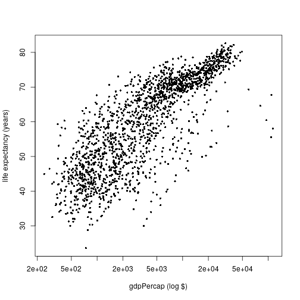

```r
pplot <- function(x, y, ...) {
      plot(x, y, pch = 16, cex = 0.6, ...)
}

pplot(gap$gdpPercap, gap$lifeExp,  xlab = 'gdpPercap (log $)',
      ylab = 'life expectancy (years)', log = 'x')
```

# Important concepts with R functions

Functions in R return an object. In general, R functions are and should be designed such that the only effect of the function is through the return value.

**Side effects** are when a function affects the state of the world in addition to its return value. Can you think of any side effects that you saw an R function produce from earlier today? What about:

- `library()`
- `setwd()`
- `plot()`

Functions in R are (roughly) *pass-by-value* and not *pass-by-reference*. This means that if you modify an argument inside the function it will not change the original value outside the function. This protects you from a major potential source of side effects. (There are exceptions to this rule.)

In actuality, functions in R are *call-by-value*. What this means for our purposes is that you can pass an input argument in without a copy being made of it. This saves time and memory. At the time that you modify the input within the function (if ever), then a copy is made and the modified input is different than the original value outside the function.

# Variable scope and global variables

In general functions should not make use of variables from outside the function. (However, for quick-and-dirty work and in some other circumstances, one may do this.) This provides modularity and reduces bugs and surprises.

If R can't find a variable that is used in a function based on the function arguments and variables defined locally in the function, it goes and looks elsewhere following a set of rules called *lexical scoping*. (This type of scoping has to do with R's roots (and explains why R is very similar to other languages for functional programming) - we won't go into details here but certainly worth looking into as you start using R more.)

Basically this means that it looks for variables relative to where the function is defined (not relative to where the function is called).

This can get involved, but a couple brief examples illustrate the basic idea.

```r
x <- 2
f <- function(y) {
    return(x + y)
}
f(1)
```

```
## [1] 3
```

```r
g <- function(y) {
  x <- 10
  return(f(y))
}

g(1)
```

```
## [1] 3
```

```r
g <- function(y) {
  f <- function(y) {
     return(x + y)
  }
  x <- 10
  return(f(y))
}

g(1)
```

```
## [1] 11
```

Note that `x` is used as a global variable here, which in general is bad practice.

# When do I start programming?

> “[W]e wanted users to be able to begin in an interactive environment, where they did not consciously think of themselves as programming. Then as their needs became clearer and their sophistication increased, they should be able **to slide gradually into programming, when the language and system aspects would become more important**.”

[John Chambers, “Stages in the Evolution of S”](http://www.stat.bell-labs.com/S/history.html)

# Key Principles of R

- Everything that exists is an object.
- Everything that happens is a function call.

[John Chambers' useR!2014 talk](http://user2014.stat.ucla.edu/files/chambers.pdf)

### What does the 2nd principle mean?

Are arithmetic operations really just functions?

```r
3+2
```

```
## [1] 5
```

```r
'+'(3,2)
```

```
## [1] 5
```

Yes!

And what about indexing?

```r
x <- matrix(runif(100), 10)
x[ , 2]
```

```
##  [1] 0.45693857 0.12290221 0.38632487 0.06402552 0.74869698 0.47714476
##  [7] 0.31106256 0.91367998 0.97745154 0.23342963
```

```r
'['(x , , 2)
```

```
##  [1] 0.45693857 0.12290221 0.38632487 0.06402552 0.74869698 0.47714476
##  [7] 0.31106256 0.91367998 0.97745154 0.23342963
```

Also yes!

This holds more generally - one can investigate and see the same thing in terms of a `for` loop.

### What does the 1st principle mean?

```r
class(1)
```

```
## [1] "numeric"
```

```r
class(runif)
```

```
## [1] "function"
```

```r
class(function(x) x^2)
```

```
## [1] "function"
```

```r
square <- function(x) x^2
class(square)
```

```
## [1] "function"
```

# Breakout

### Basics

1. Write an R function that will take an input vector and set any negative values in the vector to zero.

### Using the ideas

2. Write an R function that will take an input vector and set any value below a threshold to be the value of threshold. Optionally, the function should instead set values above a threshold to the value of the threshold.
3. Augment your function so that it checks that the input is a numeric vector and return an error if not. (See the help information for `stop()`.)
4. Figure out what `invisible()` does and why it is useful when writing functions. Use `invisible()` in your function from just above or in the `sortByCol()` function.
5. Consider the code where we used `sample()`. Initialize a storage vector of 500 zeroes. Set up a bootstrap using a for loop, with 500 bootstrap datasets. Here are the steps within each iteration:
- resample with replacement a new dataset of the same size as the actual `gap` dataset
- assign the value of the mean of the life expectancy for the bootstrap dataset into the storage vector
- repeat

Now plot a histogram of the 500 values - this is an estimate of the sampling distribution of the sample mean.

### Advanced

6. Extend the `sortByCol()` function to handle an arbitrary number of columns on which to do the sorting. You may need to modify the functionality a bit to use full vectors for the sorting rather than column names.
7. Extend the `sortByCol()` function so that it can take either numeric indices or character strings indicating columns of the input data or take entire vectors to use in the sorting of the input data. If information specifying columns is given, make sure your function carefully checks that the input refers to legitimate columns and returns an error or warning (see `warning()`) if not.
8. Explore scoping in the following code. Explain why the result is 11 and not 3. Note that `funGenerator()` returns a function as the return object, consistent with the idea that functions are objects in R. This is an example of what is called a *closure* in R. Basically, the function contains object(s) enclosed with and accessible to the function.

```r
funGenerator <- function(x) {
   x <- 10
   g <- function(y) {
      return(x + y)
   }
   return(g)
}

x <- 2
f <- funGenerator()
f(1)
```

```
## [1] 11
```

9. Suppose you wanted to do 10-fold cross-validation for some sort of regression model fit to the *gap* dataset. Write some R code that produces a field in the dataset that indicates which fold each observation is in. Ensure each of the folds has an equal (or as nearly equal as possible if the number of observations is not divisible by 10) number of observations. Hint: consider the *times* argument to the `rep()` function. (If you're not familiar with 10-fold cross-validation, it requires one to divide the dataset into 10 subsets of approximately equal size.)
10. Write some code to demonstrate the central limit theorem. Generate many different replicates of samples of size `n` from a skewed or discrete distribution and show that if `n` is big enough, the distribution of the means (of each sample of size `n`) looks approximately normal in a histogram. Do it without any looping (using techniques from earlier modules)! I.e., I want you to show that if you have a large number (say 10,000) of means, each mean being the mean of `n` values from a distribution, the distribution of the means looks approximately normal if `n` is sufficiently big.